# What do I sound like online? - Me vs. My Facebook Friends.

### A machine-learning driven exploration of online speech patterns

In this project, I want to explore several questions about my online speech patterns, as well as the speech patterns of other people. I'll be asking five main questions:

1. What words do I use that differentiate myself the greatest from my friends over Facebook Messenger?
2. Which people do I talk to on Facebook Messenger - and how frequently do I talk to each of them? Do I talk to some significantly more than others?
3. Do I use different words to talk to different people on Facebook?
4. How do I express myself differently via e-mail as opposed to via Facebook Messenger?
5. Do the emails I send contain more words on average than the messages I send on Facebook?

To answer these questions, I'll be using two primary source of data:

1. Facebook messenger data
2. GMail message data

In this notebook, I'll be exploring my Facebook messenger data. I'll attempt to answer the first three questions:

1. What words do I use that differentiate myself the greatest from my friends over Facebook Messenger?
2. Which people do I talk to on Facebook Messenger - and how frequently do I talk to each of them? Do I talk to some significantly more than others?
3. Do I use different words to talk to different people on Facebook?

**Contents**

1. Importing and parsing data
2. Initial word based classification
   - Creating training and testing bins
   - Vectorizing and classifying data
   - Testing basic model
3. Creating wrapper functions
4. Segmented classification
   - by year
   - by thread
5. Stripping out common words
   - Stripping words
   - Testing
6. Troubleshooting our model
   - Testing message lengths
   - Testing over the entire sample
7. How many people do I talk to online?
8. Do I talk do different people differently online?
9. Conclusion

## 1. Importing and Parsing Data

First, let's grab a sample of our data we created earlier.

```python
import json
```

```python
sample_data_path = "data/fb_sample_data.json"
all_data_path = "data/fb_data.json"

with open(sample_data_path, "r") as f:
    sample_data = json.load(f)

sample_data[3]
```

```
{'from': 'Talise Ti',
 'text': 'i guess :(',
 'thread_id': 958,
 'thread_members': ['Talise Ti'],
 'time': 'Wednesday, April 25, 2012 at 8:32am EDT'}
```

```python
from datetime import datetime

def parse_time_string(time_text):
    text = time_text.replace("am", "AM").replace("pm", "PM")
    time_format = "%A, %B %d, %Y at %I:%M%p %Z"
    return datetime.strptime(text, time_format)
```

```python
import pandas as pd
```

```python
df = pd.DataFrame(sample_data)
df.tail()
```

|  | from | text | thread_id | thread_members | time |
| --- | --- | --- | --- | --- | --- |
| 9995 | Kendra Cui | i think one at a time would be better | 1308 | [Kendra Cui] | Sunday, August 24, 2014 at 10:29pm EDT |
| 9996 | Brian Wong | :') | 93 | [Claudia Tam, Brian Wong, Nicole Liu] | Thursday, July 16, 2015 at 7:09am EDT |
| 9997 | Ronald Po | this isnt ur end goal | 519 | [Ronald Po] | Monday, November 12, 2012 at 10:51am EST |
| 9998 | Michael Ting | Why am I telling you this AHAHAHAJJA | 231 | [Hilary Lx, Isaac Lau, Michael Ting] | Sunday, December 15, 2013 at 6:51am EST |
| 9999 | Angelina Li | go do it | 790 | [Claudia Tam] | Sunday, April 7, 2013 at 11:30pm EDT |

```python
df["time"] = df.time.apply(parse_time_string)
df.tail()
```

|  | from | text | thread_id | thread_members | time |
| --- | --- | --- | --- | --- | --- |
| 9995 | Kendra Cui | i think one at a time would be better | 1308 | [Kendra Cui] | 2014-08-24 22:29:00 |
| 9996 | Brian Wong | :') | 93 | [Claudia Tam, Brian Wong, Nicole Liu] | 2015-07-16 07:09:00 |
| 9997 | Ronald Po | this isnt ur end goal | 519 | [Ronald Po] | 2012-11-12 10:51:00 |
| 9998 | Michael Ting | Why am I telling you this AHAHAHAJJA | 231 | [Hilary Lx, Isaac Lau, Michael Ting] | 2013-12-15 06:51:00 |
| 9999 | Angelina Li | go do it | 790 | [Claudia Tam] | 2013-04-07 23:30:00 |

```python
# just confirming that my name is in fact represented as
# "Angelina Li" here
df[df["from"] == "Angelina Li"][5:7]
```

|  | from | text | thread_id | thread_members | time |
| --- | --- | --- | --- | --- | --- |
| 10 | Angelina Li | it was very bizarre | 217 | [Faith Yeung, Caitlin Fischer, Jimin Kang, ... | 2014-06-16 00:25:00 |
| 11 | Angelina Li | ^ LOL so many memories | 54 | [Matthew Lee, Annie Kang, Haylee Wong, Shim... | 2013-09-11 09:42:00 |

```python
df["label"] = df["from"].apply(lambda name: "me" if name == "Angelina Li" else "not me")
df.tail()
```

|  | from | text | thread_id | thread_members | time | label |
| --- | --- | --- | --- | --- | --- | --- |
| 9995 | Kendra Cui | i think one at a time would be better | 1308 | [Kendra Cui] | 2014-08-24 22:29:00 | not me |
| 9996 | Brian Wong | :') | 93 | [Claudia Tam, Brian Wong, Nicole Liu] | 2015-07-16 07:09:00 | not me |
| 9997 | Ronald Po | this isnt ur end goal | 519 | [Ronald Po] | 2012-11-12 10:51:00 | not me |
| 9998 | Michael Ting | Why am I telling you this AHAHAHAJJA | 231 | [Hilary Lx, Isaac Lau, Michael Ting] | 2013-12-15 06:51:00 | not me |
| 9999 | Angelina Li | go do it | 790 | [Claudia Tam] | 2013-04-07 23:30:00 | me |

```python
df[df["label"] == "me"][5:7]
```

|  | from | text | thread_id | thread_members | time | label |
| --- | --- | --- | --- | --- | --- | --- |
| 10 | Angelina Li | it was very bizarre | 217 | [Faith Yeung, Caitlin Fischer, Jimin Kang, ... | 2014-06-16 00:25:00 | me |
| 11 | Angelina Li | ^ LOL so many memories | 54 | [Matthew Lee, Annie Kang, Haylee Wong, Shim... | 2013-09-11 09:42:00 | me |

```python
# shuffled our sample!
shuffled_df = df.sample(frac=1, random_state=2).reset_index(drop=True)
shuffled_df[25:30]
```

|  | from | text | thread_id | thread_members | time | label |
| --- | --- | --- | --- | --- | --- | --- |
| 25 | Angelina Li | I knew that | 1183 | [Thomas Zhang] | 2013-01-01 00:56:00 | me |
| 26 | Angelina Li | ok what about after sdc everyone who's there g... | 393 | [Caitlin Fischer, Madhav Menon, Claudia Tam,... | 2013-04-11 09:18:00 | me |
| 27 | Angelina Li | because you dont delegate to a leader | 1296 | [Leo Ji] | 2014-11-09 07:26:00 | me |
| 28 | Ben Muschol | The companies that manufacture the drugs have ... | 720 | [Ben Muschol] | 2017-02-16 18:54:00 | not me |
| 29 | Jason Lam | Err what else | 362 | [Dennis Lui, Christy Tsang, Jason Lam, Hele... | 2014-02-11 10:21:00 | not me |

Looks good! Now, we can grab our training and testing datasets.

## 2. Initial classification

### a. Creating training and testing bins

```python
all_text = shuffled_df["text"].tolist()
all_labels = shuffled_df["label"].tolist()

count = len(all_text)
halfway = int(count/2)
assert count == len(all_labels)

train_text = all_text[:halfway]
train_labels = all_labels[:halfway]

test_text = all_text[halfway:]
test_labels = all_labels[halfway:]
print(len(train_text), len(test_text))
```

```
5000 5000
```

```python
print("text:", train_text[7], "| label:", train_labels[7])
```

```
text: I can't even begin to describe what I feel | label: not me
```

### b. Vectorizing and classifying data

Now that we have our data, we can use a Multinomial Naive Bayes classifier to classify our data. First, let's vectorize our data.

```python
from sklearn.feature_extraction.text import CountVectorizer
```

```python
vectorizer = CountVectorizer()
x_train = vectorizer.fit_transform(train_text)
x_train
```

```
<5000x5631 sparse matrix of type '<class 'numpy.int64'>'
	with 32104 stored elements in Compressed Sparse Row format>
```

```python
print(vectorizer.get_feature_names()[30:50])
```

```
['1_sshaupocqhhfk', '1a6l3iahsp7cwrpbcggxxroog3chcexkew06usrw3', '1j8judumcemwqw1utz6hl1y9', '1miv6r47rixcmoi6rjyfmjkkn8npv55tlfbbhu2cbyby', '1p6u7zl3j5hrn2fzz', '1pm', '1q3swhuwtrt9yz5to_9_3sm_eaaccsjcgg6onbp9o9kc', '1st', '1swr2j5qmr2j0l1ln9ve233', '1zpd12r1agzzlabv_ys8wn6qmie8syinrsxdhwceofzi', '…
```

```python
print(len(vectorizer.get_feature_names()))
```

```
5631
```

```python
vectorizer
```

```
CountVectorizer(analyzer='word', binary=False, decode_error='strict',
        dtype=<class 'numpy.int64'>, encoding='utf-8', input='content',
        lowercase=True, max_df=1.0, max_features=None, min_df=1,
        ngram_range=(1, 1), preprocessor=None, stop_words=None,
        strip_accents=None, token_pattern='(?u)\\b\\w\\w+\\b',
        tokenizer=None, vocabulary=None)
```

Now, we can train our classifier.

```python
from sklearn.naive_bayes import MultinomialNB
classifier = MultinomialNB()
classifier.fit(x_train, train_labels)
```

```
MultinomialNB(alpha=1.0, class_prior=None, fit_prior=True)
```

```python
classifier.classes_
```

```
array(['me', 'not me'],
      dtype='<U6')
```

```python
classifier.feature_log_prob_.shape
```

```
(2, 5631)
```

```python
# first 10 parameters of probability distribution P(w|c="me")
classifier.feature_log_prob_[0][:10]
```

```
array([-10.13114092,  -9.43799374,  -9.43799374, -10.13114092,
        -9.43799374,  -9.43799374, -10.13114092,  -9.43799374,
        -8.05169938,  -8.52170301])
```

```python
# first 10 parameters of probability distribution P(w|c="not me")
classifier.feature_log_prob_[1][:10]
```

```
array([-9.23410573, -9.23410573, -9.92725291, -9.23410573, -9.92725291,
       -9.92725291, -9.23410573, -9.92725291, -7.36230355, -8.82864062])
```

### c. Testing our basic classifier

Let's classify some new text as either 'me' or 'not me'!

```python
test_vector = vectorizer.transform(test_text)
test_vector
```

```
<5000x5631 sparse matrix of type '<class 'numpy.int64'>'
	with 29138 stored elements in Compressed Sparse Row format>
```

```python
import numpy as np

accuracy = 0
test_indices = range(10)
for i in test_indices:
    case = test_vector[i]
    predicted_label = classifier.predict(case[0])[0]
    actual_label = test_labels[i]
    if predicted_label == actual_label:
        accuracy += 1
    print("text:", test_text[i], "\n\tpredicted label:",
          predicted_label, "\n\tactual label:", actual_label)

print("\n{} correct out of {}".format(accuracy, len(test_indices)))
```

```
text: 10, 20, 50 cents
	predicted label: not me
	actual label: me
text: why not
	predicted label: not me
	actual label: me
text: *Madam, Madame is french lol
	predicted label: me
	actual label: not me
text: giraffe giraffe
	predicted label: not me
	actual label: me
text: HI :D
	predicted label: me
	actual label: me
text: claudia XD
	predicted label: me
	actual label: me
text: it's not particularly............ just.. moody idk
	predicted label: me
	actual label: me
text: wait
	predicted label: me
	actual label: not me
text: thats pretty thoughtful
	predicted label: me
	actual label: me
text: but how will you know if you don't at least repeat your experiment? :)
	predicted label: not me
	actual label: me

4 correct out of 10
```

It looks like our classifier is not doing that great - it's not even getting half of our messages labelled right. Let's see how it performs on average.

```python
accuracy = 0
for i, actual_label in enumerate(test_labels):
    case = test_vector[i]
    predicted_label = classifier.predict(case[0])[0]
    if predicted_label == actual_label:
        accuracy += 1

print("{} out of {} correct, with an accuracy rate of {}%.".format(
    accuracy, len(test_text), round(100*accuracy/len(test_text), 3)))
```

```
2978 out of 5000 correct, with an accuracy rate of 59.56%.
```

This accuracy rate isn't great. One thing it might suggest is that my text conversations, as represented as a "bag of words", might not be that distinct from the "bag of words" that my friends use online.

One thing that this multinomial naive bayes classifier might be able to tell me is: Which words do I use that most distinctly set me apart from my friends?

Thanks to these pages for teaching me how to extract the most informative features:

- https://stackoverflow.com/questions/29867367/sklearn-multinomial-nb-most-informative-features
- https://stackoverflow.com/questions/11116697/how-to-get-most-informative-features-for-scikit-learn-classifiers

```python
def get_best_features(vectorizer, classifier, n=30):
    feature_names = vectorizer.get_feature_names()
    # coefficients are for the words I most distinctly use as opposed to others
    assert len(classifier.coef_[0]) == len(feature_names)
    coefs = sorted(zip(classifier.coef_[0], feature_names), reverse=True)

    print("coef\tword")
    print("============")
    for i in range(n):
        coef, word = coefs[i]
        print("{}\t{}".format(round(coef, 4), word))

get_best_features(vectorizer, classifier)
```

```
coef	word
============
-3.8705	the
-4.0084	to
-4.1131	you
-4.3899	and
-4.4018	it
-4.6855	is
-4.7288	that
-4.7915	of
-4.7974	for
-4.8153	we
-4.871	so
-4.8774	in
-4.9436	but
-5.1232	have
-5.1911	my
-5.2544	just
-5.2544	can
-5.2638	like
-5.3525	not
-5.3629	if
-5.3629	be
-5.384	on
-5.384	me
-5.4055	are
-5.4164	was
-5.4164	do
-5.5328	what
-5.5834	with
-5.5834	this
-5.6646	at
```

It looks like a lot of the words that this classifier is putting weight on are very generic words. That's really interesting - it suggests that perhaps, subtle differences in the frequencies with which I use seemingly 'generic' words are really what characterize my speaking style online, as compared to the speaking styles of my friends.

One possibility for why this classifier might be performing poorly is that my speaking style (and the speaking style of my friends) might be changing significantly over time, such that the 'time trends' in my speaking habits might make it very difficult for the classifier to pick out any specific words that differentiate me from others.

Let's try to 'control' for this by restricting our classification process to within each year.

First, let's create some 'wrapper functions' that can replicate the process we've already gone through for us.

## 3. Creating wrapper functions

```python
def get_overall_df(list_of_messages):
    """
    Given a list of message dictionaries (in the form of the
    json files we've been working out of), will return a formatted,
    shuffled dataframe of all messages.
    """
    df = pd.DataFrame(list_of_messages)
    df["time"] = df.time.apply(parse_time_string)
    df["label"] = df["from"].apply(
        lambda name: "me" if name == "Angelina Li" else "not me")
    df = df.sample(frac=1, random_state=2).reset_index(drop=True)
    return df
```

```python
def get_train_test_data(df):
    all_text = df["text"].tolist()
    all_labels = df["label"].tolist()

    halfway = int(len(all_text)/2)
    train_text = all_text[:halfway]
    train_labels = all_labels[:halfway]
    test_text = all_text[halfway:]
    test_labels = all_labels[halfway:]

    return {
        "train_text": train_text,
        "train_labels": train_labels,
        "test_text": test_text,
        "test_labels": test_labels
    }
```

```python
def get_accuracy(vectorizer, classifier, data):
    test_vector = vectorizer.transform(data["test_text"])
    accuracy = 0
    for i, actual_label in enumerate(data["test_labels"]):
        case = test_vector[i]
        predicted_label = classifier.predict(case[0])[0]
        if predicted_label == actual_label:
            accuracy += 1
    return {
        "accuracy": accuracy,
        "n": len(data["test_text"]),
    }

def get_accuracy_top_features(df, get_data, top_features=30):
    """
    Given a shuffled dataframe, will print information about
    the accuracy of the Multinomial NB classifier on these data,
    as well as the most predictive features the classifier has access to.

    df: The dataframe over which to create training and testing data from.
    get_data: Function that takes in a dataframe and returns a dictionary
    of training and testing data.
    """
    data = get_data(df)

    vectorizer = CountVectorizer()
    x_train = vectorizer.fit_transform(data["train_text"])

    classifier = MultinomialNB()
    classifier.fit(x_train, data["train_labels"])

    acc = get_accuracy(vectorizer, classifier, data)
    print("ACCURACY\n========")
    print("{} out of {} correct, with an accuracy rate of {}%.\n".format(
        acc["accuracy"],
        acc["n"],
        round(100*acc["accuracy"]/acc["n"], 3)
    ))

    get_best_features(vectorizer, classifier, top_features)
```

Checking that our wrapper functions work as intended:

```python
test_df = get_overall_df(sample_data)
```

```python
get_accuracy_top_features(test_df, get_train_test_data, top_features=15)
```

```
ACCURACY
========
2978 out of 5000 correct, with an accuracy rate of 59.56%.

coef	word
============
-3.8705	the
-4.0084	to
-4.1131	you
-4.3899	and
-4.4018	it
-4.6855	is
-4.7288	that
-4.7915	of
-4.7974	for
-4.8153	we
-4.871	so
-4.8774	in
-4.9436	but
-5.1232	have
-5.1911	my
```

## 4. Segmented classification

Looks good! Now, we need to additionally repeat this process for every year.

### a. Classification by year

```python
def get_info_year(year, main_df, get_data, top_features=30):
    main_df[year] = main_df["time"].apply(lambda time: time.year == year)
    year_df = main_df[main_df[year] == True]
    main_df.drop([year], axis=1)

    print("\nIn year {}:\n".format(year))
    get_accuracy_top_features(year_df, get_data, top_features)
```

```python
for year in range(2015, 2018):
    get_info_year(year, test_df, get_train_test_data, top_features=10)
```

```
In year 2015:

ACCURACY
========
484 out of 802 correct, with an accuracy rate of 60.349%.

coef	word
============
-4.1011	to
-4.1799	you
-4.359	the
-4.5531	it
-4.8251	and
-4.8896	is
-4.8896	for
-4.9586	we
-4.995	so
-5.0327	in

In year 2016:

ACCURACY
========
345 out of 593 correct, with an accuracy rate of 58.179%.

coef	word
============
-3.9609	the
-4.0281	to
-4.3729	it
-4.4546	and
-4.5206	you
-4.6938	we
-4.7784	for
-4.839	is
-4.9374	that
-4.9374	of

In year 2017:

ACCURACY
========
724 out of 1202 correct, with an accuracy rate of 60.233%.

coef	word
============
-3.932	the
-4.0335	to
-4.1464	you
-4.5573	and
-4.6428	that
-4.6609	is
-4.6792	it
-4.8615	for
-4.9546	we
-4.9546	but
```

### b. Classification by thread

We could also look specifically at the differences in the speech patterns between me and a specific person, in case my speech patterns differ wildly between different conversation threads.

Here, Facebook makes life easy for us - each message in our dataframe already comes with a thread_id denoting a conversation with any given person.

We can find the people I talk to the most on Facebook, and see what speech patterns separate myself from my conversation partners.

First, let's find the people I talk to the most on Facebook.

```python
from collections import Counter

def get_top_threads(n, main_df):
    thread_counts = Counter(main_df["thread_id"].tolist())
    return thread_counts.most_common(n)

get_top_threads(5, test_df)
```

```
[(720, 1671), (881, 465), (846, 280), (96, 240), (673, 230)]
```

Let's figure out who these people are!

```python
def get_top_conversations(n, main_df):
    top_threads = get_top_threads(n, main_df)
    top_individuals = {}
    for thread_id, count in top_threads:
        match_id = main_df["thread_id"] == thread_id
        match_label = main_df["label"] == "not me"
        temp_df = main_df[match_id & match_label]
        name = temp_df["thread_members"].iloc[0]
        top_individuals[thread_id] = {
            "name": name,
            "count": count}
    return top_individuals

get_top_conversations(5, test_df)
```

```
{96: {'count': 240,
  'name': ['Alan Gigi',
   ' Caitlin Fischer',
   ' Aspen Wang',
   ' Madhav Menon',
   ' Claudia Tam',
   ' Anson Cheung',
   ' Lucien Wang',
   ' Zed Levy',
   ' Nicole Liu',
   ' Petra Ho']},
 673: {'count': 230, 'name': ['Ben Feshbach']},
 720: {'count': 1671, 'name': ['Ben Muschol']},
 846: {'count': 280, 'name': ['Isaac Lau']},
 881: {'count': 465, 'name': ['Laurence Yuen']}}
```

Now, let's partition our data such that we train our classifier on data for each specific conversation thread.

```python
def get_thread_df(thread_id, main_df):
    """
    Return a dataframe of all data that matches this thread number
    """
    return main_df[main_df["thread_id"] == thread_id]

def get_info_conversations(main_df, get_data, top_features=10, top_friends=5):
    top_threads = get_top_conversations(top_friends, main_df)

    for thread_id, info_dict in top_threads.items():
        thread_df = get_thread_df(thread_id, main_df)

        print("\nFRIEND: {}; COUNT: {}\n".format(
            info_dict["name"], info_dict["count"])
        )
        get_accuracy_top_features(thread_df, get_data, top_features)
```

```python
get_info_conversations(test_df, get_train_test_data)
```

```
FRIEND: ['Ben Muschol']; COUNT: 1671

ACCURACY
========
556 out of 836 correct, with an accuracy rate of 66.507%.

coef	word
============
-3.895	the
-4.5201	to
-4.7237	you
-4.8996	that
-4.9796	just
-5.0222	is
-5.0666	but
-5.1131	it
-5.1131	for
-5.1619	and

FRIEND: ['Laurence Yuen']; COUNT: 465

ACCURACY
========
149 out of 233 correct, with an accuracy rate of 63.948%.

coef	word
============
-4.2204	the
-4.281	it
-4.3455	and
-4.4886	you
-4.5687	to
-4.6557	in
-4.751	with
-4.8564	that
-4.9741	my
-5.1077	of

FRIEND: ['Isaac Lau']; COUNT: 280

```

[output cut: 39 more lines]

```
========
71 out of 115 correct, with an accuracy rate of 61.739%.

coef	word
============
-4.3694	to
-4.503	you
-4.503	the
-4.6571	it
-4.8395	on
-4.8395	have
-4.8395	also
-4.8395	about
-5.0626	that
-5.0626	so
```

Here is a head to head comparison of how our segmented classifications did as compared to our basic classifier:

1. Overall accuracy: 59.56%
2. Classification by year:
   - 2015 classification: 60.349%
   - 2016 classification: 58.179%
   - 2017 classification: 60.233%
3. Classification by thread:
   - Thread 1 classification: 66.507%
   - Thread 2 classification: 63.948%
   - Thread 3 classification: 60.0%
   - Thread 4 classification: 69.167%
   - Threat 5 classification: 61.739%

It looks like, on average, our segmented classifications did slightly better than our main classifier. This makes sense based on our initial motivations going into this process: it might be the case that my speaking style varies too drastically across years or across different conversation threads for our main classifier to pick out many distinct words that most significantly predict whether a given text message was written by me or by someone else.

Notice that our segments by thread classifications also seem slightly more accurate than our general classifier - again, this makes sense under our given rationale because controlling for different individuals I have conversations with implicitly sets impositions on time lengths as well - for instance, 2 out of the 5 threads I've seen the most conversations in were started only after my sophomore year of college (2016) - thus implicitly controlling for some of the changes in my speaking style across time.

## 5. Stripping out common words

From all the analysis we've done so far, it seems like one of the big problem with our classifier is that it is getting confused based on irrelevant, relatively common words.

What might help us parse out the truly unique words that I use as compared to other people, is if we first cleaned our data of some common English words.

To accomplish this, I'll use a list of the top 10,000 English words as determined by [Google's Trillion Word Corpus](https://books.google.com/ngrams/info). Thanks to [first20hours](https://github.com/first20hours/google-10000-english) for making this list open source. I'll parse out the top 500 words from all the text in my messages.

### a. Stripping out words

First, let's create some functions that can help us create a testing dataset stripped of potentially misleading words.

```python
top_words = []
with open("data/google-10000-english.txt") as words:
    for _ in range(500):
        top_words.append(words.readline().strip())
top_words[:10]
```

```
['the', 'of', 'and', 'to', 'a', 'in', 'for', 'is', 'on', 'that']
```

```python
import re

top_regex = ["^{}$".format(word) for word in top_words]
regex_match = "|".join(top_regex)
regex_match[:100]
```

```
'^the$|^of$|^and$|^to$|^a$|^in$|^for$|^is$|^on$|^that$|^by$|^this$|^with$|^i$|^you$|^it$|^not$|^or$|^'
```

```python
def strip_common_words(s):
    all_words = re.sub("[^a-zA-Z\d\s]", "", s).split()
    strip_text = lambda word: re.sub(regex_match, "", word, flags=re.IGNORECASE)
    stripped = map(strip_text, all_words)
    all_words = list(filter(lambda s: s != "", stripped))
    return " ".join(all_words).strip()
```

```python
strip_common_words("just testing out the most boring words")
```

```
'testing boring words'
```

```python
strip_common_words("it is sunny today")
```

```
'sunny'
```

```python
strip_common_words("the of and to a in for is on that")
```

```
''
```

```python
strip_common_words("Here is an EXAMple!!!! of? a potentially messy string :D")
```

```
'EXAMple potentially messy string'
```

We want to preserve our data the way it was originally, such that our training data reflect data we might genuinely receive.

To do this, let's edit how we generate training and testing data.

```python
def strip_tuple(tup):
    text, label = tup
    return (strip_common_words(text), label)

def get_train_test_stripped(df):
    all_text = df["text"].tolist()
    all_labels = df["label"].tolist()

    halfway = int(len(all_text)/2)

    train_data = zip(all_text[:halfway], all_labels[:halfway])
    train_data = filter(lambda tup: tup[0], map(strip_tuple, train_data))

    train_text, train_labels = zip(*list(train_data))

    test_text = all_text[halfway:]
    test_labels = all_labels[halfway:]

    return {
        "train_text": train_text,
        "train_labels": train_labels,
        "test_text": test_text,
        "test_labels": test_labels
    }
```

```python
data = get_train_test_stripped(test_df)
data["train_text"][20:25]
```

```
('concert',
 'younger study crude psychology ferociously wanted others convinced meaning existence tool happiness everyone',
 'RCHK major problem',
 'knew',
 'ok sdc everyone whos together CWB earrings')
```

```python
data["train_labels"][15:20]
```

```
('not me', 'me', 'not me', 'me', 'not me')
```

### b. Testing

Looks good! Let's see if this helps us to increase the accuracy of our classifier.

```python
get_accuracy_top_features(test_df, get_train_test_stripped, top_features=15)
```

```
ACCURACY
========
2743 out of 5000 correct, with an accuracy rate of 54.86%.

coef	word
============
-4.4836	im
-5.1619	dont
-5.1918	lol
-5.3039	yeah
-5.3561	oh
-5.5972	ill
-5.6438	okay
-5.6438	ok
-5.7438	thanks
-5.7705	thats
-5.7979	omg
-5.9157	sure
-5.9157	sorry
-5.9157	haha
-6.0141	youre
```

```python
get_info_conversations(test_df, get_train_test_stripped)
```

```
FRIEND: ['Ben Muschol']; COUNT: 1671

ACCURACY
========
547 out of 836 correct, with an accuracy rate of 65.431%.

coef	word
============
-4.8765	im
-5.0707	yeah
-5.5125	nice
-5.5125	dont
-5.6303	oh
-5.6303	idk
-5.6303	gonna
-5.7638	wow
-5.7638	thing
-5.7638	bad

FRIEND: ['Laurence Yuen']; COUNT: 465

ACCURACY
========
149 out of 233 correct, with an accuracy rate of 63.948%.

coef	word
============
-4.9402	dont
-5.1634	tell
-5.1634	pretty
-5.1634	lol
-5.1634	im
-5.1634	hrm
-5.1634	dude
-5.451	yo
-5.451	xd
-5.451	thats

FRIEND: ['Isaac Lau']; COUNT: 280

```

[output cut: 39 more lines]

```
========
67 out of 115 correct, with an accuracy rate of 58.261%.

coef	word
============
-4.3307	im
-4.5539	round
-4.5539	lol
-4.5539	idk
-4.5539	haha
-4.8416	yeah
-4.8416	wait
-4.8416	thoughts
-4.8416	ppl
-4.8416	ill
```

```python
for year in range(2015, 2018):
    get_info_year(year, test_df, get_train_test_stripped, top_features=10)
```

```
In year 2015:

ACCURACY
========
477 out of 802 correct, with an accuracy rate of 59.476%.

coef	word
============
-4.6118	im
-5.305	dont
-5.392	yeah
-5.4873	youre
-5.4873	lol
-5.5926	omg
-5.5926	haha
-5.7104	xd
-5.7104	wait
-5.7104	tomorrow

In year 2016:

ACCURACY
========
345 out of 593 correct, with an accuracy rate of 58.179%.

coef	word
============
-4.2678	im
-4.9311	yeah
-4.9917	dont
-5.2794	sorry
-5.4617	oh
-5.6849	tomorrow
-5.8184	wow
-5.8184	thats
-5.8184	sounds
-5.8184	okay

In year 2017:

ACCURACY
========
682 out of 1202 correct, with an accuracy rate of 56.739%.

coef	word
============
-4.6037	im
-5.3575	dont
-5.491	yeah
-5.491	sure
-5.491	oh
-5.7322	thanks
-5.7322	something
-5.8275	nice
-5.8275	meeting
-5.8275	lol
```

It doesn't seem like stripping common words has helped much in this context, and has in fact worsened the performance of our basic classifier. Thus, it is likely not at the root of our troubles.

## 6. Examining our basic classifier

I think, besides a genuine lack of features that set my speaking style online apart from the speaking style of my friends, that there might be two alternative reasons why our classifier might be underperforming:

1. Each individual message contains too little information to be classified.
2. Our sample size is too small - we should instead use the entire population of Facebook messages we have access to.

Let's test both of these assumptions!

### a. What if each message is too short?

If the real problem here is that each individual message is too short to be classified in full, we can instead create testing data by randomly generating artificial 'messages' from our overall text messages of varying lengths and seeing whether longer messages fare significantly better under our classification model.

We can also plot the OLS relationship between the length of each message we've classified so far and the likelihood it was classified correctly. If there is a significantly positive relationship between length of message and a correct classification, this might suggest that our classifier is not equipped to deal with small chunks of text.

Let's implement the first test first, and feed our classifier a "bag of words" to train and test.

```python
def get_labelled_bag_words(text, labels):
    labelled_bag = {}

    for i, text in enumerate(text):
        label = labels[i]
        if label not in labelled_bag:
            labelled_bag[label] = []
        labelled_bag[label].append(text)

    for label in labelled_bag:
        labelled_bag[label] = " ".join(labelled_bag[label])

    return labelled_bag

def get_train_test_words(df):
    all_text = df["text"].tolist()
    all_labels = df["label"].tolist()

    halfway = int(len(all_text)/2)
    train_text = all_text[:halfway]
    train_labels = all_labels[:halfway]

    test_bag = get_labelled_bag_words(all_text[halfway:], all_labels[halfway:])
    test_text = list(test_bag.values())
    test_labels = list(test_bag.keys())

    return {
        "train_text": train_text,
        "train_labels": train_labels,
        "test_text": test_text,
        "test_labels": test_labels
    }
```

```python
import random
```

```python
def make_sample_test_data(text, labels, len_message, num_samples=500):
    """
    This function will artificially create random 'messages' made up of
    words selected randomly from each bin. It will generate an approximately
    equal number of messages for each label category.
    """
    new_labels = []
    new_text = []

    assert len(text) == len(labels)
    old_data = zip(labels, text)

    for l, t in old_data:
        text_words = t.split()
        for _ in range(int(num_samples/2)):
            new_msg = " ".join(random.sample(text_words, len_message))
            new_text.append(new_msg)
            new_labels.append(l)
    return {
        "test_labels": new_labels,
        "test_text": new_text
    }

def get_accuracy_bag_words(df):
    data = get_train_test_words(df)

    vectorizer = CountVectorizer()
    x_train = vectorizer.fit_transform(data["train_text"])

    classifier = MultinomialNB()
    classifier.fit(x_train, data["train_labels"])

    accuracy_len = {}
    for len_msg in range(10, 301, 10):
        test_data = make_sample_test_data(
            data["test_text"], data["test_labels"], len_msg)
        acc = get_accuracy(vectorizer, classifier, test_data)
        accuracy_len[len_msg] = acc["accuracy"]/acc["n"]
    return accuracy_len
```

```python
accuracy_by_len = get_accuracy_bag_words(test_df)
```

```python
accuracy_by_len
```

```
{10: 0.588,
 20: 0.654,
 30: 0.652,
 40: 0.702,
 50: 0.676,
 60: 0.712,
 70: 0.712,
 80: 0.722,
 90: 0.718,
 100: 0.732,
 110: 0.74,
 120: 0.704,
 130: 0.768,
 140: 0.744,
 150: 0.716,
 160: 0.758,
 170: 0.766,
 180: 0.772,
 190: 0.776,
 200: 0.764,
 210: 0.784,
 220: 0.764,
 230: 0.764,
 240: 0.766,
 250: 0.804,
 260: 0.77,
 270: 0.768,
 280: 0.75,
 290: 0.77,
 300: 0.752}
```

```python
%matplotlib inline
import matplotlib.pyplot as plt
import seaborn as sns

sns.set(style="ticks")
```

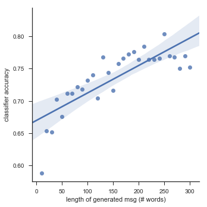

```python
len_df = pd.DataFrame({
    "length of generated msg (# words)": list(accuracy_by_len.keys()),
    "classifier accuracy": list(accuracy_by_len.values())
})

sns.lmplot(
    x="length of generated msg (# words)",
    y="classifier accuracy",
    data=len_df
)
```

This plot indeed seems to demonstrate to us that longer messages are classified more readily under our classification model.

As an additional test, we can also plot the relationship between the length of messages in our testing data and the accuracy of the classifier in classifying them, and see if this relationship bears out in that context.

```python
def get_len_accuracy_dict(df):
    """
    Returns a dictionary plotting the average accuracy of a classifier for each text length.
    """
    data = get_train_test_data(df)

    vectorizer = CountVectorizer()
    x_train = vectorizer.fit_transform(data["train_text"])

    classifier = MultinomialNB()
    classifier.fit(x_train, data["train_labels"])

    test_vector = vectorizer.transform(data["test_text"])

    len_accuracy = {}

    for i, actual_label in enumerate(data["test_labels"]):
        text_len = len(data["test_text"][i])

        case = test_vector[i]
        predicted_label = classifier.predict(case[0])[0]
        correct = 1 if predicted_label == actual_label else 0

        if text_len not in len_accuracy:
            len_accuracy[text_len] = []
        len_accuracy[text_len].append(correct)

    for text_len in len_accuracy:
        len_accuracy[text_len] = np.mean(len_accuracy[text_len])

    return len_accuracy
```

```python
actual_accuracy_by_len = get_len_accuracy_dict(test_df)
```

```python
sorted(list(actual_accuracy_by_len.items()))[:20]
```

```
[(0, 0.55714285714285716),
 (1, 0.58139534883720934),
 (2, 0.578125),
 (3, 0.61538461538461542),
 (4, 0.59405940594059403),
 (5, 0.55833333333333335),
 (6, 0.63809523809523805),
 (7, 0.52713178294573648),
 (8, 0.61739130434782608),
 (9, 0.52542372881355937),
 (10, 0.59433962264150941),
 (11, 0.6428571428571429),
 (12, 0.58510638297872342),
 (13, 0.61467889908256879),
 (14, 0.54166666666666663),
 (15, 0.63095238095238093),
 (16, 0.54081632653061229),
 (17, 0.57831325301204817),
 (18, 0.58241758241758246),
 (19, 0.62637362637362637)]
```

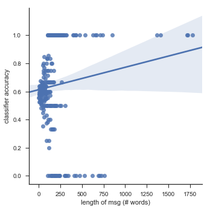

```python
len_df = pd.DataFrame({
    "length of msg (# words)": list(actual_accuracy_by_len.keys()),
    "classifier accuracy": list(actual_accuracy_by_len.values())
})

sns.lmplot(
    x="length of msg (# words)",
    y="classifier accuracy",
    data=len_df
)
```

Our actual data seem to also demonstrate the notion that our classifier performs better at classifying longer messages, although there is enough variance in our data that we perhaps can't be certain of this relationship.

Nevertheless, it seems like this general relationship could explain some of the problems with our classifier.

### b. What if we aren't using enough data?

Everything we've done up until this point has been to work with a sample of 10,000 messages from my entire Facebook messenger history. While this certainly seems like a considerable sample size, it might be that our classifier is so data hungry that a training dataset of a mere 5,000 messages is insufficient.

We can test this notion by using all the data we have access to and running our classifier as we did previously.

```python
with open(all_data_path, "r") as f:
    all_messenger_data = json.load(f)

all_df = get_overall_df(all_messenger_data)
```

```python
all_df.count()
```

```
from              532108
text              532108
thread_id         532108
thread_members    532108
time              532108
label             532108
dtype: int64
```

Now that we have access to all of our data, let's run our basic classifier, as well as our segmented classifiers on this dataset.

```python
get_accuracy_top_features(all_df, get_train_test_data, top_features=30)
```

```
ACCURACY
========
176776 out of 266054 correct, with an accuracy rate of 66.444%.

coef	word
============
-3.6096	the
-3.693	to
-3.8211	you
-4.1	it
-4.1014	and
-4.3919	that
-4.4569	is
-4.5182	of
-4.5785	in
-4.6463	we
-4.6608	for
-4.6734	so
-4.837	have
-4.8564	but
-4.8904	be
-4.9738	can
-5.0179	on
-5.0234	like
-5.0518	my
-5.0621	do
-5.0735	just
-5.1103	this
-5.1226	are
-5.1405	me
-5.1472	not
-5.1776	if
-5.3161	with
-5.3188	was
-5.3252	what
-5.337	at
```

```python
for year in range(2015, 2018):
    get_info_year(year, all_df, get_train_test_data, top_features=10)
```

```
In year 2015:

ACCURACY
========
29906 out of 43292 correct, with an accuracy rate of 69.08%.

coef	word
============
-3.6707	the
-3.8132	to
-3.8539	you
-4.1153	it
-4.2053	and
-4.5436	is
-4.5882	we
-4.6	that
-4.6254	of
-4.626	in

In year 2016:

ACCURACY
========
21768 out of 32312 correct, with an accuracy rate of 67.368%.

coef	word
============
-3.6182	the
-3.6523	to
-3.8812	you
-4.1395	and
-4.1544	it
-4.3393	that
-4.5023	is
-4.5439	in
-4.5451	so
-4.5596	of

In year 2017:

ACCURACY
========
42215 out of 63281 correct, with an accuracy rate of 66.71%.

coef	word
============
-3.648	to
-3.6845	the
-3.7734	you
-4.0944	it
-4.1672	and
-4.2516	that
-4.4707	is
-4.5609	of
-4.6247	in
-4.6701	for
```

```python
get_info_conversations(all_df, get_train_test_data)
```

```
FRIEND: ['Ben Muschol']; COUNT: 91703

ACCURACY
========
32719 out of 45852 correct, with an accuracy rate of 71.358%.

coef	word
============
-3.6286	the
-3.8783	to
-3.9402	you
-4.1506	that
-4.1815	it
-4.408	is
-4.4229	and
-4.5493	so
-4.6026	of
-4.6817	like

FRIEND: ['Laurence Yuen']; COUNT: 24775

ACCURACY
========
9279 out of 12388 correct, with an accuracy rate of 74.903%.

coef	word
============
-3.7612	the
-3.7696	you
-3.7707	to
-4.1714	it
-4.2235	and
-4.2696	that
-4.5095	of
-4.6707	is
-4.7608	in
-4.8661	my

FRIEND: ['Isaac Lau']; COUNT: 14890

```

[output cut: 39 more lines]

```
========
3412 out of 5341 correct, with an accuracy rate of 63.883%.

coef	word
============
-3.4798	you
-3.9495	to
-4.0525	the
-4.4763	it
-4.5711	and
-4.682	in
-4.7391	that
-4.7997	so
-4.8717	is
-4.8792	for
```

Here is a head to head comparison of the gains in accuracy from using our entire population:

1. Overall accuracy: 59.56% --> 66.444%
2. Classification by year:
   - 2015 classification: 60.349% --> 69.08%
   - 2016 classification: 58.179% --> 67.368%
   - 2017 classification: 60.233% --> 66.71%
3. Classification by thread:
   - Thread 1 classification: 66.507% --> 71.358%
   - Thread 2 classification: 63.948% --> 74.903%
   - Thread 3 classification: 60.0% --> 71.135%
   - Thread 4 classification: 69.167% --> 79.58%
   - Last thread omitted - the 5th most frequent person I talked to changed when considering the entire population!

Looking at these results, it certainly seems like increasing our sample size helped us somewhat in training our classifier. Furthermore, it is reassuring to note here that the basic results we found in the segmented classification section still hold - it seems like we can improve the accuracy of our classifier quite significantly by "controlling" for thread.

For reasons already discussed above, "controlling" for thread in this context both implicitly controls for year and also controls for the subtle differences in how I speak to different people online.

Nevertheless, in absolute terms our classifier still performs relatively poorly, only classifying messages correctly around 66.44% of the time.

## 7. Which people do I talk to most frequently online?

It seems as though, from the above exploration I've done, that I talk to some people significantly more than I talk to other people. I think it'd be interesting to see whether this is true in general throughout all the people I talk to.

```python
# Show top friends, as well as counts
def show_top_friends(main_df, n=20):
    all_data = get_top_conversations(n, main_df).values()
    percentage = [100*dct["count"]/len(main_df.index) for dct in all_data]
    names = [", ".join(dct["name"]) for dct in all_data]
    return pd.DataFrame({"name": names, "percentage": percentage})

show_top_friends(test_df, 15)
```

|  | name | percentage |
| --- | --- | --- |
| 0 | Ben Muschol | 16.71 |
| 1 | Laurence Yuen | 4.65 |
| 2 | Isaac Lau | 2.80 |
| 3 | Alan Gigi, Caitlin Fischer, Aspen Wang, Mad... | 2.40 |
| 4 | Ben Feshbach | 2.30 |
| 5 | Claudia Tam | 2.00 |
| 6 | Ananya Hariharan | 1.97 |
| 7 | Michelle Yu | 1.96 |
| 8 | Hilary Lx | 1.96 |
| 9 | Julian Wan | 1.95 |
| 10 | Jennifer Beveridge, George Jolly, Alisha Pra... | 1.94 |
| 11 | Michelle Lam | 1.85 |
| 12 | Faith Yeung, Caitlin Fischer, Jimin Kang, C... | 1.85 |
| 13 | Brian Wong | 1.84 |
| 14 | April Chen, Ellen Hao | 1.66 |

```python
def get_all_threads(main_df):
    thread_counts = Counter(main_df["thread_id"].tolist())
    all_counts = sorted(list(thread_counts.items()), key=lambda tup: tup[1], reverse=True)
    len_main_df = len(main_df.index)
    return [(i, all_counts[i][0], 100*all_counts[i][1]/len_main_df) for i in range(len(all_counts))]
```

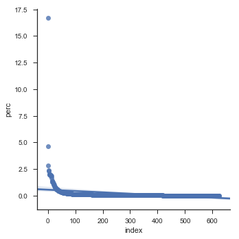

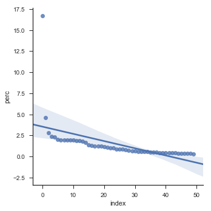

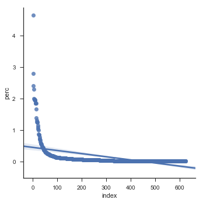

```python
def plot_data(df, title):
    sns.lmplot(
        x="index",
        y="perc",
        data=df
    )

def plot_threads(main_df):
    ordered_threads = get_all_threads(main_df)
    i, thread_num, perc = zip(*ordered_threads)
    plot_data(pd.DataFrame({"index": i, "perc": perc}), "All data")

    # We can also look at the top 50 to get a closer look
    plot_data(pd.DataFrame({"index": i[:50], "perc": perc[:50]}), "Top 50")

    # And let's also drop the first result, which seems unusual and is restricting our ability to see the shape
    # of the rest of our data
    plot_data(pd.DataFrame({"index": i[1:], "perc": perc[1:]}), "Top 2 onwards")

plot_threads(test_df)
```

It looks like I do seem to talk to basically only a few people online. Even after dropping the first, pretty anomalous result from our dataset, it still seems like I talk almost entirely to a very small group of individuals. Let's see if this finding holds up in the dataset at large.

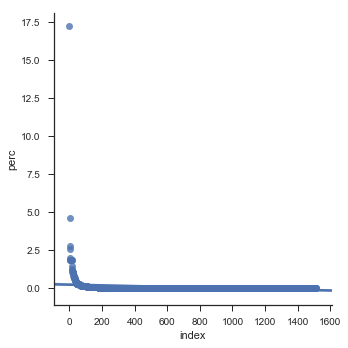

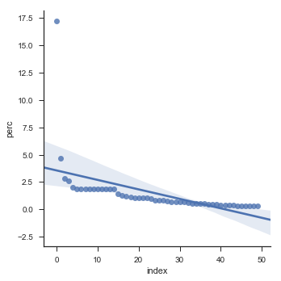

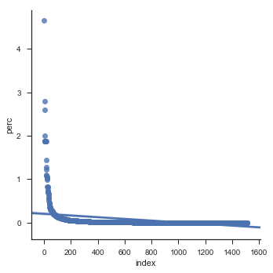

```python
plot_threads(all_df)
```

Looks like this finding holds up well! We can conclude that it seems like I talk to a pretty small number of individuals on Facebook messenger.

## 8. Do I talk to different people differently online?

Previously, the question we were mostly focused on is whether I talk differently from other people online. I think it'd also be interesting to look at my speech patterns when talking with different friends, and see whether or not there are significant differences in the way I talk to some people as compared to others.

In this section, I'll pull data from the five friends I talk to the most online, and will see whether or not a Multinomial Naive Bayes classifier can distinguish between whether I talk to each friend in a different way.

```python
def get_messages_to(main_df, thread_id):
    """
    Return a list of messages I've sent in a particular thread
    """
    match_id = main_df["thread_id"] == thread_id
    match_label = main_df["label"] == "me"
    df = main_df[match_id & match_label]
    return df["text"].tolist()

def get_friends_train_test(main_df, top_friends=5):
    top_threads = get_top_conversations(top_friends, main_df)

    all_labels = []
    all_text = []
    for thread_id, info_dict in top_threads.items():
        text = get_messages_to(main_df, thread_id)
        labels = [",".join(info_dict["name"]) for _ in range(len(text))]
        all_text.extend(text)
        all_labels.extend(labels)

    assert len(all_labels) == len(all_text)
    all_data = list(zip(all_labels, all_text))
    np.random.shuffle(all_data)
    all_labels, all_text = zip(*all_data)

    halfway = int(len(all_text)/2)

    return {
        "train_text": all_text[:halfway],
        "train_labels": all_labels[:halfway],
        "test_text": all_text[halfway:],
        "test_labels": all_labels[halfway:]
    }
```

```python
def get_friends_best_features(vectorizer, classifier, n=30):
    feature_names = vectorizer.get_feature_names()
    friend_labels = classifier.classes_
    print("TOP FEATURES\n============")

    if len(friend_labels) != 2: # considered binary
        for i, label in enumerate(friend_labels):
            top_features = np.argsort(classifier.coef_[i])[-n:]
            print("* {}: {}".format(
                label,
                ", ".join(feature_names[j] for j in top_features)
            ))

    else:
        top_features = np.argsort(classifier.coef_[0])[-n:]
        print("* {}: {}".format(
            friend_labels[0],
            ", ".join(feature_names[j] for j in top_features)
        ))
```

```python
def get_friends_info(main_df, top_friends=5, top_features=30):
    data = get_friends_train_test(main_df, top_friends)

    vectorizer = CountVectorizer()
    x_train = vectorizer.fit_transform(data["train_text"])

    classifier = MultinomialNB()
    classifier.fit(x_train, data["train_labels"])

    acc = get_accuracy(vectorizer, classifier, data)
    print("ACCURACY\n========")
    print("{} out of {} correct, with an accuracy rate of {}%.\n".format(
        acc["accuracy"],
        acc["n"],
        round(100*acc["accuracy"]/acc["n"], 3)
    ))

    get_friends_best_features(vectorizer, classifier, n=top_features)
```

```python
get_friends_info(test_df, top_friends=10, top_features=10)
```

```
ACCURACY
========
558 out of 1138 correct, with an accuracy rate of 49.033%.

TOP FEATURES
============
* Alan Gigi, Caitlin Fischer, Aspen Wang, Madhav Menon, Claudia Tam, Anson Cheung, Lucien Wang, Zed Levy, Nicole Liu, Petra Ho: and, the, you, my, if, to, is, that, it, at
* Ananya Hariharan: it, but, and, like, ll, you, be, for, the, to
* Ben Feshbach: of, with, has, in, and, good, you, that, the, to
* Ben Muschol: my, of, like, so, is, that, the, and, you, to
* Claudia Tam: haha, so, you, nice, are, and, is, art, xd, that
* Hilary Lx: xd, busy, know, do, just, get, to, and, the, you
* Isaac Lau: lol, have, that, if, and, the, it, of, to, you
* Julian Wan: and, not, so, just, for, like, it, you, to, the
* Laurence Yuen: me, of, is, so, it, and, that, you, the, to
* Michelle Yu: get, we, its, on, in, it, to, and, you, the
```

```python
get_friends_info(test_df, top_friends=5, top_features=10)
```

```
ACCURACY
========
562 out of 880 correct, with an accuracy rate of 63.864%.

TOP FEATURES
============
* Alan Gigi, Caitlin Fischer, Aspen Wang, Madhav Menon, Claudia Tam, Anson Cheung, Lucien Wang, Zed Levy, Nicole Liu, Petra Ho: was, if, you, is, that, it, at, and, to, the
* Ben Feshbach: in, with, like, good, so, and, the, you, that, to
* Ben Muschol: it, my, of, is, that, so, and, you, the, to
* Isaac Lau: would, or, and, do, so, if, of, the, to, you
* Laurence Yuen: me, lol, of, can, and, that, it, is, to, the
```

```python
get_friends_info(test_df, top_friends=2, top_features=10)
```

```
ACCURACY
========
558 out of 709 correct, with an accuracy rate of 78.702%.

TOP FEATURES
============
* Ben Muschol: not, my, so, is, and, the, lol, that, you, to
```

It looks like our classifier does pretty well, particularly when only comparing between a small number of candidates (and perhaps between only the starkest of differences). We could also try this out on our overall population:

```python
get_friends_info(all_df, top_friends=10, top_features=10)
```

```
ACCURACY
========
33080 out of 59161 correct, with an accuracy rate of 55.915%.

TOP FEATURES
============
* Alan Gigi, Caitlin Fischer, Aspen Wang, Madhav Menon, Claudia Tam, Anson Cheung, Lucien Wang, Zed Levy, Nicole Liu, Petra Ho: that, so, of, is, lol, it, and, the, to, you
* Ben Feshbach: but, it, of, so, that, is, and, you, the, to
* Ben Muschol: like, it, is, so, that, of, and, you, the, to
* Brian Wong: but, just, yeah, of, like, it, and, you, the, to
* Claudia Tam: is, xd, lol, so, like, it, and, the, to, you
* Isaac Lau: that, in, and, is, lol, of, it, the, you, to
* Jennifer Beveridge, George Jolly, Alisha Pradhan, Wing Yung Ng, Sabrina Au, Rotem Wiersch, Jordan Jeynes, Isabel Lwin May Khine, Louis Hardy: is, in, can, of, you, it, and, we, the, to
* Laurence Yuen: in, like, that, it, of, lol, and, you, the, to
* Michelle Lam: is, lol, of, it, so, like, and, to, the, you
* Michelle Yu: just, we, of, in, so, it, and, the, you, to
```

```python
get_friends_info(all_df, top_friends=5, top_features=10)
```

```
ACCURACY
========
32735 out of 47278 correct, with an accuracy rate of 69.239%.

TOP FEATURES
============
* Alan Gigi, Caitlin Fischer, Aspen Wang, Madhav Menon, Claudia Tam, Anson Cheung, Lucien Wang, Zed Levy, Nicole Liu, Petra Ho: so, of, is, that, it, lol, and, the, to, you
* Ben Muschol: like, it, so, is, of, that, and, you, the, to
* Isaac Lau: lol, in, that, is, and, of, it, you, the, to
* Laurence Yuen: like, in, that, it, of, lol, and, the, you, to
* Michelle Yu: we, just, in, of, it, so, and, the, you, to
```

```python
get_friends_info(all_df, top_friends=2, top_features=10)
```

```
ACCURACY
========
32628 out of 38629 correct, with an accuracy rate of 84.465%.

TOP FEATURES
============
* Ben Muschol: is, so, that, it, lol, of, and, you, the, to
```

It seems like there are notable features of my language that change based on who I'm talking to online. As with the first classification task, it's interesting that a lot of these features are so subtle - they don't rely on any particularly notable words, but rather on the frequency with which I use common words with different people.

## 9. Concluding reflections

Nevertheless, I still learned several interesting things about my habits on Facebook messenger:

1. A surprising fact I uncovered through this project was the fact that I seem to spend a very significant amount of time talking to very few people. The person I talk to by far the most online makes up around 17.234% (91703/532108) of my overall online interactions.
2. Most of the words that seem to best predict whether a text message is from me as opposed to from someone else are surprisingly mundane. The top 10 features (run on the entire population) are: the, to, you, it, and, that, is, of, in, we. On the one hand, this seemingly random set of words might serve to prove the point that a "bag of words" construct is a poor representation of actual speech, that loses some of the nuances of when we use words and for what reason. On the other hand, it's interesting to think that perhaps there are subtle differences in the frequency with which I use certain words (which I am not even aware of myself) are really what distinguishes me from other people online.
3. It seems like I do "[code switch](https://en.wikipedia.org/wiki/Code-switching)" when talking to different people online in subtle ways.